Peer-graded Assignment: Course Project 1

### Loading and preprocessing the data

```r
url <- 'https://d396qusza40orc.cloudfront.net/repdata%2Fdata%2Factivity.zip'
download.file(url, method = "curl", destfile = "activity.zip")
unzip("./activity.zip")
activity <- read.csv("activity.csv", stringsAsFactors = FALSE)
activity$date <-  as.POSIXct(activity$date, format="%Y-%m-%d")
summary(activity)
```

```
##      steps             date                        interval
##  Min.   :  0.00   Min.   :2012-10-01 00:00:00   Min.   :   0.0
##  1st Qu.:  0.00   1st Qu.:2012-10-16 00:00:00   1st Qu.: 588.8
##  Median :  0.00   Median :2012-10-31 00:00:00   Median :1177.5
##  Mean   : 37.38   Mean   :2012-10-30 23:32:27   Mean   :1177.5
##  3rd Qu.: 12.00   3rd Qu.:2012-11-15 00:00:00   3rd Qu.:1766.2
##  Max.   :806.00   Max.   :2012-11-30 00:00:00   Max.   :2355.0
##  NA's   :2304
```

```r
dim(activity)
```

```
## [1] 17568     3
```

### 1. What is mean total number of steps taken per day?

Calculate the total number of steps taken per day

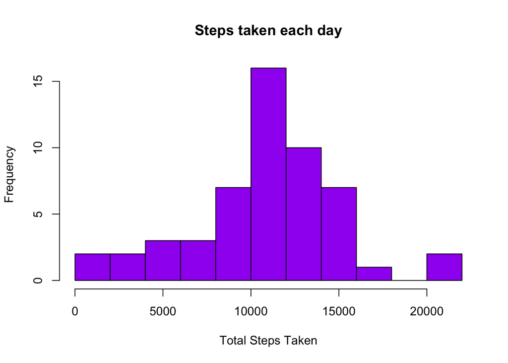

```r
stepsTotal <- aggregate(steps ~ date, data = activity, FUN = sum, na.rm = TRUE)
hist(stepsTotal$steps, col = "purple", xlab = "Total Steps Taken", main = "Steps taken each day", breaks = "FD")
```

Calculate and report the mean and median of the total number of steps taken per day

```r
mean(stepsTotal$steps)
```

```
## [1] 10766.19
```

```r
median(stepsTotal$steps)
```

```
## [1] 10765
```

### 2. What is the average daily activity pattern?

Average steps taken within a day calculated

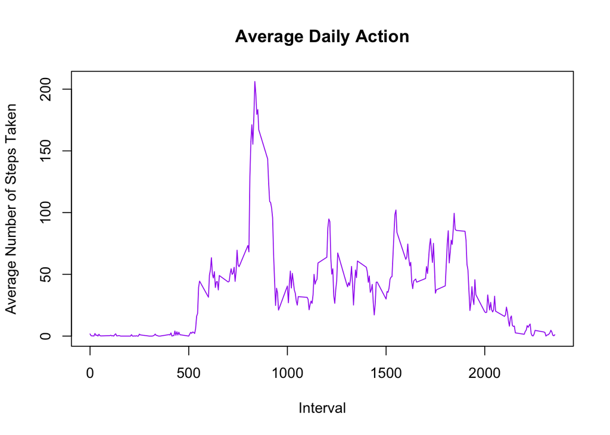

```r
daily <- aggregate(steps ~ interval, data = activity, FUN = mean, na.rm = TRUE)
plot(x = daily$interval, y = daily$steps, type = "l", main = "Average Daily Action", ylab = "Average Number of Steps Taken", xlab= "Interval", col = "purple")
```

Which 5-minute interval, on average across all the days in the data set, contains the maximum number of steps?

```r
daily$interval[which.max(daily$steps)]
```

```
## [1] 835
```

### 3. Imputing missing values

Calculate and report missing values in the data set

```r
sum(is.na(activity))
```

```
## [1] 2304
```

```r
sum(is.na(activity$steps))
```

```
## [1] 2304
```

As values above are the same, only missing values are in column “steps”

Devise a strategy for filling in all of the missing values in the data set

```r
activity$day <- weekdays(activity$date)
activity$week <- ""
activity[activity$day == "Saturday" | activity$day == "Sunday", ]$week <- "weekend"
activity[! (activity$day == "Saturday" | activity$day == "Sunday"), ]$week <- "weekday"
```

```r
missing <- aggregate(steps ~ interval+day, data = activity, median, na.rm= TRUE)
```

```r
activity2 <- merge(activity, missing, by = c("day", "interval"))
activity2$stepsNew <- ifelse(is.na(activity2$steps.x), activity2$steps.y, activity2$steps.x)
```

Make a histogram of the total number of steps taken each day

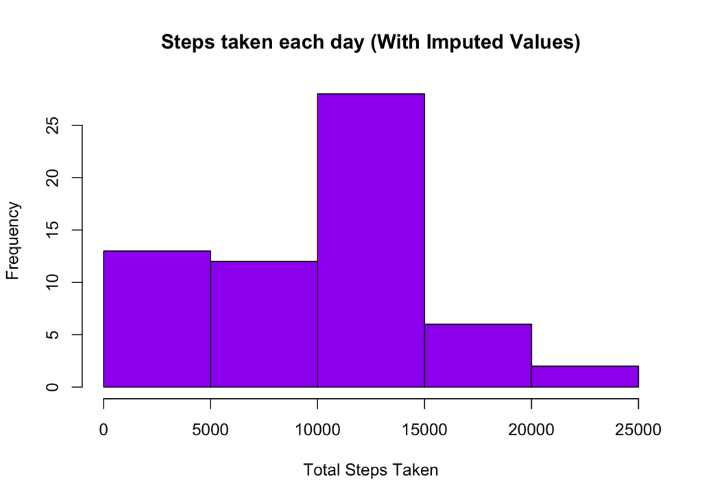

```r
stepsTotal2 <- aggregate(stepsNew ~ date, data = activity2, FUN = sum)
hist(stepsTotal2$stepsNew, col = "purple", xlab = "Total Steps Taken", main = "Steps taken each day (With Imputed Values)", breaks = "FD")
```

Do these values differ from the estimates from the first part of the assignment? What is the impact of imputing missing data on the estimates of the total daily number of steps?

Total count of steps increased by:

```r
sum(activity2$stepsNew) - sum(activity$steps, na.rm = TRUE)
```

```
## [1] 21411.5
```

### 4. Are there differences in activity patterns between weekdays and weekends?

“weekday” & “weekend” variable created above. Average value for factor variables computed

```r
seven <- aggregate(stepsNew ~ interval+week, activity2, mean)
```

Chart created

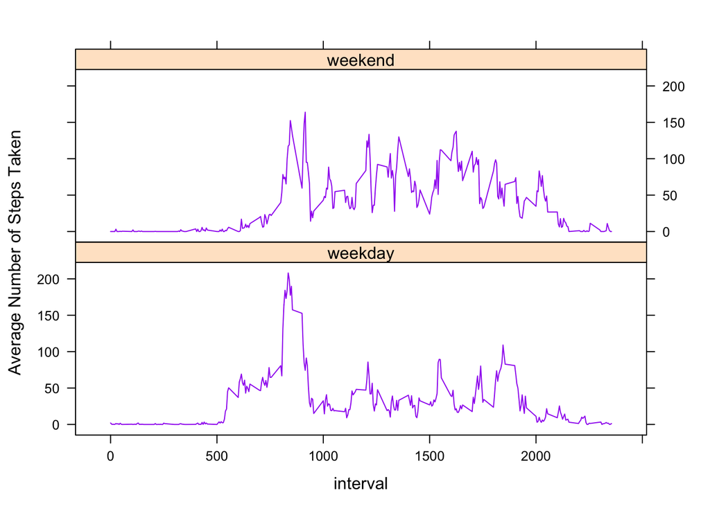

```r
library(lattice)
par(mfrow=c(2, 1))

xyplot(stepsNew ~ interval | week, seven, type = "l", layout = c(1,2), ylab = "Average Number of Steps Taken", col = "purple")
```